# Exploring the BRFSS data

## Setup

### Load packages

```r
library(ggplot2)
library(dplyr)
```

### Load data

```r
load("brfss2013.RData")
```

## Part 1: Data

The Behavioral Risk Factor Surveillance System (BRFSS) is a collaborative project between all of the states in the United States (US) and participating US territories and the Centers for Disease Control and Prevention (CDC). BRFSS is an ongoing surveillance system designed to measure behavioral risk factors for the non-institutionalized adult population (18 years of age and older) residing in the US.

### Collection of data

We can learn about the sampling methods from the [BRFSS Data User Guide](http://www.cdc.gov/brfss/data_documentation/pdf/userguidejune2013.pdf). Since 2011, BRFSS conducts both landline telephone- and cellular telephone-based surveys. In conducting the BRFSS landline telephone survey, interviewers collect data from a randomly selected adult in a household. In conducting the cellular telephone version of the BRFSS questionnaire, interviewers collect data from an adult who participates by using a cellular telephone and resides in a private residence or college housing.

### Generalizability

As it stands, the BRFSS should generalize to all adults (18-years and older) who are household members since the phone numbers are selected by some form of random sampling. The user guide notes that other nations are setting up similar surveys. However, we should not try to generalize to the global adult population for a variety of reasons. **the access to landlines and cellular telephones is not similar from country to country.**

### Causality

The BRFSS data is observational not experimental. Even though the phone numbers are randomly selected, the subjects are *not* randomly assigned to experimental study groups because of following reason **State-added Questions: States are encouraged to gather data on additional topics related to their specific health priorities.** Therefore, we can only show a correlation/association, not a causation.

## Part 2: Research questions

**Research quesion 1:**

Is there any correlation between sex “sex” and exercise time “exerhmm1” of person.Are there any difference based on income “income2”.? I really more interested in causal relationships but this is only an observational study.

**Research quesion 2:**

Is there any correlation between income “income2” and person Could Not See Dr. Because Of Cost “medcost”. We are interested to find that income really effects that person could not able to See Doctor.

**Research quesion 3:** Is there any correlation between smokers “smoke100” and education level “educa” of person. Are there any difference based on sex “sex? we are interested to find that education levels effects a person smoke or not? if they smoke then percentage of Male and Female?

## Part 3: Exploratory data analysis

**Research quesion 1:**

```r
data_narm <- brfss2013 %>% select(income2, exerhmm1, sex) %>% filter(!is.na(income2), !is.na(exerhmm1), !is.na(sex))

data_narm %>% group_by(income2) %>% summarise(meanexer=mean(exerhmm1), totalexer=sum(exerhmm1), female_per=sum(sex == "Female") / n(), Male_per=sum(sex=="Male")/n())
```

```
## # A tibble: 8 x 5
##   income2           meanexer totalexer female_per Male_per
##   <fct>                <dbl>     <int>      <dbl>    <dbl>
## 1 Less than $10,000     98.2   1340889      0.652    0.348
## 2 Less than $15,000     92.3   1320899      0.635    0.365
## 3 Less than $20,000     95.1   1854993      0.627    0.373
## 4 Less than $25,000     95.2   2333614      0.617    0.383
## 5 Less than $35,000     92.5   2842005      0.594    0.406
## 6 Less than $50,000     93.6   3905989      0.568    0.432
## 7 Less than $75,000     91.2   4334955      0.554    0.446
## 8 $75,000 or more       91.7   8397787      0.514    0.486
```

[figure not shown]

```r
levels(data_narm$income2) <- gsub(" ", "\n",levels(data_narm$income2))
ggplot(data = data_narm, aes(x = income2,fill = sex)) +
geom_bar() +
labs(title="income vs total exercise in minutes", x="income", y="total exercise(in minutes)")
```

**Research quesion 2:**

```r
data <- brfss2013 %>% select(income2, medcost) %>% filter(!is.na(income2), !is.na(medcost))
result <- data %>% group_by(income2) %>% summarise(NotSeeDr = sum(medcost=="Yes")/n())
result
```

```
## # A tibble: 8 x 2
##   income2           NotSeeDr
##   <fct>                <dbl>
## 1 Less than $10,000   0.288
## 2 Less than $15,000   0.256
## 3 Less than $20,000   0.232
## 4 Less than $25,000   0.199
## 5 Less than $35,000   0.146
## 6 Less than $50,000   0.105
## 7 Less than $75,000   0.0706
## 8 $75,000 or more     0.0350
```

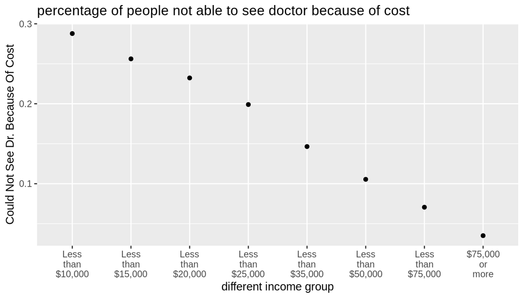

```r
levels(result$income2) <- gsub(" ", "\n",levels(result$income2))
ggplot(result, aes(income2, NotSeeDr))+
geom_point(aes(income2, NotSeeDr))+
labs(title="percentage of people not able to see doctor because of cost",y="Could Not See Dr. Because Of Cost",x="different income group")
```

There is strong relationship between income levels and percentage of people not able to see doctor because of cost. lower income group most likely not able to see doctor because of cost and these percentage decreasing on increasing income levels.

**Research quesion 3:**

```r
rq3 <- brfss2013 %>% select(educa, smoke100, sex) %>% filter(!is.na(educa), !is.na(smoke100), !is.na(sex))
rq <- rq3 %>% group_by(educa) %>% summarise(smoke = sum(smoke100=="Yes")/n(), male_per = sum(sex=="Male")/n(), female_per = sum(sex=="Female")/n() )
rq
```

```
## # A tibble: 6 x 4
##   educa                                           smoke male_per female_per
##   <fct>                                           <dbl>    <dbl>      <dbl>
## 1 Never attended school or only kindergarten      0.348    0.403      0.597
## 2 Grades 1 through 8 (Elementary)                 0.465    0.428      0.572
## 3 Grades 9 though 11 (Some high school)           0.599    0.400      0.600
## 4 Grade 12 or GED (High school graduate)          0.512    0.405      0.595
## 5 College 1 year to 3 years (Some college or tec… 0.484    0.382      0.618
## 6 College 4 years or more (College graduate)      0.350    0.433      0.567
```

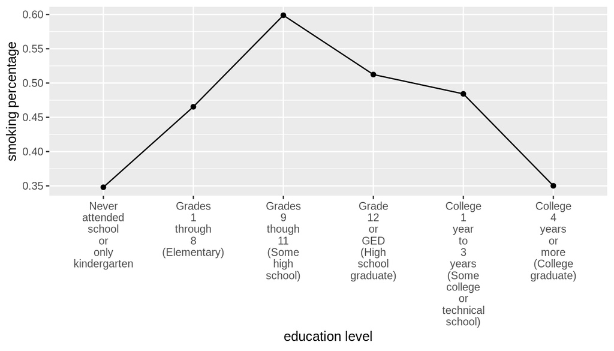

```r
levels(rq$educa) <- gsub(" ", "\n",levels(rq$educa))
ggplot(rq, aes(x=educa, y=smoke))+geom_point()+
geom_path(group=1)+
labs(x="education level", y="smoking percentage")
```

[figure not shown]

```r
levels(rq3$educa) <- gsub(" ", "\n",levels(rq3$educa))
ggplot(data = rq3, aes(x = educa,fill = sex)) +
geom_bar() +
labs(title="", x="different education level", y="Proportion of male and female in different education levels")
```